# MATH 241: Homework 05

Miguel Conner

Due Wednesday 2015/4/29 1:00pm on Moodle

Please indicate

- Approximately how much time you spent on this homework: 4
- What, if anything, gave you an exceeding amount of trouble? By exceeding I mean above and beyond run-of-the-mill difficulties when learning new things.

```
## [1] "Using direct authentication"
```

## Question 1:

Let’s analyze some of the text from the following sources:

1. Reed College subreddit,
2. Portland subreddit,
3. A scraping of all tweets using a word, hashtag, Twitter ID of your choice for a given date range defined by `start.date` and `end.date` (geo-location is optional),
4. Sir Arthur Conan Doyle’s novel called The Lost World [Project Gutenberg](http://www.gutenberg.org/).

I’ll present the top `n` “interesting” words used in each of the four data sets, in a word cloud and a data table.

Many thanks to Mitchell Linegar for gathering the data. The python code used to scrape the data can be found [here](https://github.com/mlinegar/RedditScraping).

```r
# Define parameters.
n <- 30                     # Number of words in word cloud.
nt <- 1000                 # Number of tweets searched.
start.date <- "2015-01-01"  # Start date of Twitter search.
end.date <- "2015-04-30"    # End date of Twitter search.
topic <- "data science"     # 'topic' defines what is searched in Twitter.
```

### Reed College subreddit

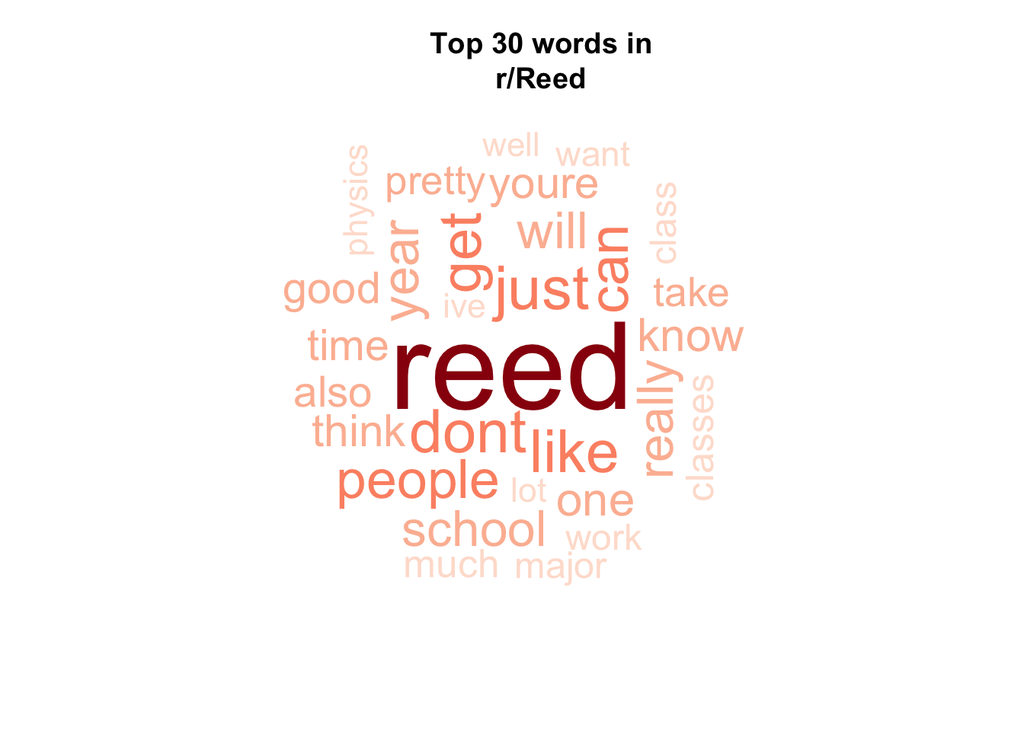

We see that a lot of the words indicate personal opinions, presumably becuase the subreddit is filled with questions from prospective students which are then answered by current students.

|  | Word | Counts |
| --- | --- | --- |
| 1 |  | [998] |
| 2 | reed | [726] |
| 3 | im | [380] |
| 4 | just | [322] |
| 5 | dont | [319] |
| 6 | like | [315] |
| 7 | get | [302] |
| 8 | can | [289] |
| 9 | people | [280] |
| 10 | year | [266] |

[output cut: 20 more lines]

### Portland subreddit

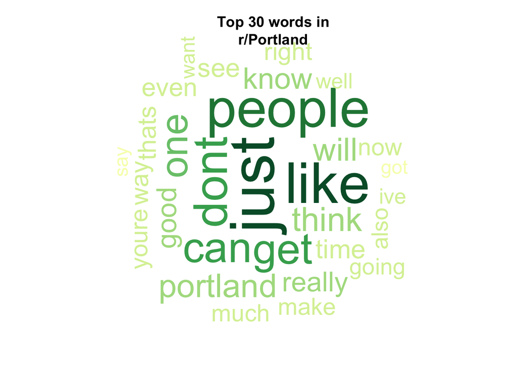

It’s difficult to find a really clear topic or pattern, but it appears that many of the words have positive associatios (e.g. “like”,“good”,“well”, “think”, “make”).

|  | Word | Counts |
| --- | --- | --- |
| 1 |  | [11095] |
| 2 | just | [1854] |
| 3 | like | [1692] |
| 4 | people | [1622] |
| 5 | im | [1455] |
| 6 | dont | [1366] |
| 7 | can | [1232] |
| 8 | get | [1230] |
| 9 | one | [1088] |
| 10 | think | [918] |

[output cut: 20 more lines]

### Twitter

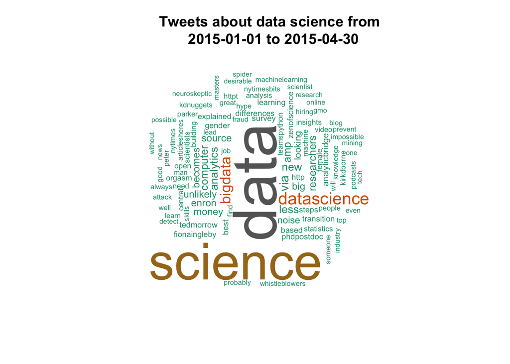

|  | Word | Counts |
| --- | --- | --- |
| 1 | data | [921] |
| 2 | science | [761] |
| 3 | rt | [468] |
| 4 | datascience | [185] |
| 5 | bigdata | [142] |
| 6 | via | [111] |
| 7 | analytics | [87] |
| 8 | less | [85] |
| 9 | new | [84] |
| 10 | computer | [81] |

[output cut: 40 more lines]

### The Lost World – Sir Arthur Conan Doyle

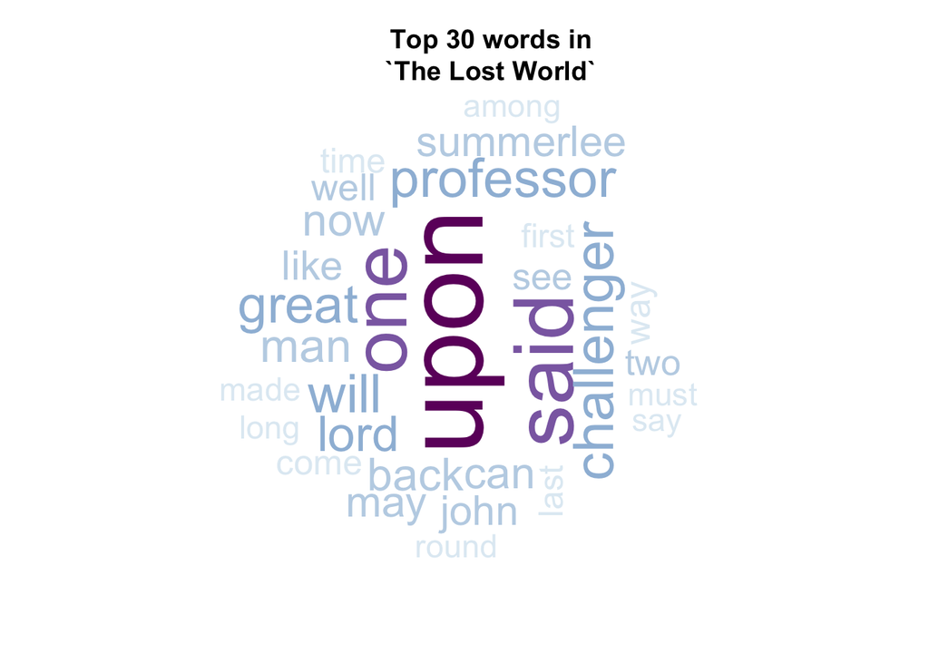

With the word cloud we get a sense for some of the characters in the novel (i.e. professor Challenger, professor Summerlee, and lord John Roxton).

|  | Word | Counts |
| --- | --- | --- |
| 1 | upon | [407] |
| 2 | us | [325] |
| 3 | said | [296] |
| 4 | one | [270] |
| 5 | challenger | [184] |
| 6 | professor | [177] |
| 7 | will | [174] |
| 8 | great | [170] |
| 9 | lord | [156] |
| 10 | man | [147] |

[output cut: 20 more lines]